# Домашнее задание №1 - Метод К-ближайших соседей (K-neariest neighbors)

Сегодня мы с вами реализуем наш первый алгоритм машинного обучения, метод К-ближайших соседей. Мы попытаемся решить с помощью него задачи:

- бинарной классификации (то есть, только двум классам)
- многоклассовой классификации (то есть, нескольким классам)
- регрессии (когда зависимая переменная - натуральное число)

Так как методу необходим гиперпараметр (hyperparameter) - количество соседей, то нам нужно научиться подбирать этот параметр. Мы постараемся научиться пользовать numpy для векторизованных вычислений, а также посмотрим на несколько метрик, которые используются в задачах классификации и регрессии.

Перед выполнением задания:

- установите все необходимые библиотеки, запустив `pip install -r requirements.txt`

Если вы раньше не работали с numpy или позабыли его, то можно вспомнить здесь:  
http://cs231n.github.io/python-numpy-tutorial/

```python
import time
import matplotlib.pyplot as plt
import seaborn as sns
import numpy as np
import random
import pandas as pd


from sklearn.datasets import fetch_openml
from sklearn.model_selection import train_test_split
from knn import KNNClassifier
from metrics import binary_classification_metrics, multiclass_accuracy
```

```python
# plt.rcParams["figure.figsize"] = 12, 9
sns.set_style("whitegrid")

SEED = 111
random.seed(SEED)
np.random.seed(SEED)
```

```python
%load_ext autoreload
%autoreload 2
```

## Задание 1. KNN на датасете Fashion-MNIST (10 баллов)

В этом задании вам предстоит поработать с картинками одежды, среди которых можно выделить 10 классов. Данные уже загружены за вас: в переменной X лежат 70000 картинок размером 28 на 28 пикселей, вытянутые в вектор размерностью 784 (28 * 28). Так как данных довольно много, а наш KNN будет весьма медленный, то возьмем случайно 1000 наблюдений (в реальности в зависимости от вашей реализации можно будет взять больше, но если будет не зватать ОЗУ, то берите меньше).

```python
X, y = fetch_openml(name="Fashion-MNIST", return_X_y=True, as_frame=False)
```

```python
idx_to_stay = np.random.choice(np.arange(X.shape[0]), replace=False, size=1000)
X = X[idx_to_stay]
y = y[idx_to_stay]
```

Давайте посмотрим на какое-нибудь изображение из наших данных:

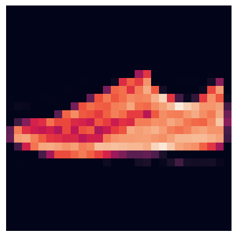

```python
# возьмем случайную картинку и сделаем reshape
# 28, 28, 1 = H, W, C (число каналов, в данном случае 1)
image = X[np.random.choice(np.arange(X.shape[0]))].reshape(28, 28, 1)
plt.imshow(image)
plt.axis("off");
```

### 1.1. Посмотрим на все классы (0.5 баллов)

Возьмите по одной картинке каждого класса и изобразите их (например, сделайте subplots 5 на 2).

```python
classes = np.unique(y)
```

```python
Y_series = pd.Series(y)

indexes = []
for i in range(10):
    indexes.append(Y_series.loc[Y_series == str(i)].index[0])
```

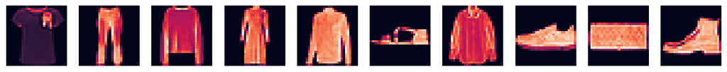

```python
images = []
for i in indexes:
    images.append(X[i])

fig, axs = plt.subplots(1, 10, figsize=(15, 5))

for i in range(0, 10):
    axs[i].imshow(images[i].reshape(28,28,1))
    axs[i].axis('off')
```

### 1.2. Сделайте небольшой EDA (1 балл)

Посмотрите на баланс классов. В дальнейших домашках делайте EDA, когда считаете нужным, он нужен почти всегда, но оцениваться это уже не будет, если не будет указано иное. Делайте EDA, чтобы узнать что-то новое о данных!

```python
pd.Series(y).describe()
```

```
count     1000
unique      10
top          3
freq       121
dtype: object
```

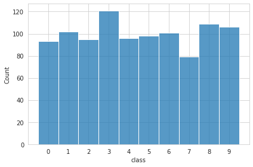

```python
fig, axes = plt.subplots(figsize=(6, 4), tight_layout=True);
sns.histplot(sorted(y));
plt.xlabel('class');
```

### 1.3. Разделите данные на train и test (0.5 баллов)

Разделите данные на тренировочную и тестовую выборки, размеры тестовой выборки выберите сами. Здесь вам может помочь функция `train_test_split`

```python
X_train, X_test, y_train, y_test = train_test_split(X, y, test_size=0.2)
```

### 1.4. KNN для бинарной классификации (6 баллов)

Давайте возьмем для задачи бинарной классификации только объекты с метками классов 0 и 1.

```python
binary_train_y = y_train[(y_train == '1') | (y_train == '0')]
binary_train_X = X_train[:binary_train_y.shape[0]]

binary_test_y = y_test[(y_test == '1') | (y_test == '0')]
binary_test_X = X_test[:binary_test_y.shape[0]]
```

И вот мы подготовили данные, но модели у нас пока что нет. В нескольких занятиях нашего курса вам придется самостоятельно реализовывать какие-то алгоритмы машинного обучения, а потом сравнивать их с готовыми библиотечными решениями. В остальных заданиях реализовывать алгоритмы будет не обязательно, но может быть полезно, поэтому часто это будут задания на дополнительные баллы, но главное не это, а понимание работы алгоритма после его реализации с нуля на простом numpy. Также это все потом можно оформить в виде репозитория ml_from_scratch и хвастаться перед друзьями.

```python
knn_classifier = KNNClassifier(k=1)
knn_classifier.fit(binary_train_X, binary_train_y)
```

### Настало время писать код!

В KNN нам нужно для каждого тестового примера найти расстояния до всех точек обучающей выборки. Допустим у нас 1000 примеров в train'е и 100 в test'е, тогда в итоге мы бы хотели получить матрицу попарных расстояний (например, размерностью 100 на 1000). Это можно сделать несколькими способами, и кому-то наверняка, в голову приходит идея с двумя вложенными циклами (надеюсь, что не больше:). Так можно делать, то можно и эффективнее. Вообще, в реальном KNN используется структура данных [k-d-tree](https://ru.wikipedia.org/wiki/K-d-%D0%B4%D0%B5%D1%80%D0%B5%D0%B2%D0%BE), которая позволяет производить поиск за log(N), а не за N, как будем делать мы (по сути это такое расширение бинарного поиска на многомерное пространство).

Вам нужно будет последовательно реализовать методы `compute_distances_two_loops`, `compute_distances_one_loop` и `compute_distances_no_loops` класса `KNN` в файле `knn.py`.

Эти функции строят массив расстояний между всеми векторами в тестовом наборе и в тренировочном наборе.  
В результате они должны построить массив размера `(num_test, num_train)`, где координата `[i][j]` соотвествует расстоянию между i-м вектором в test (`test[i]`) и j-м вектором в train (`train[j]`).

**Обратите внимание** Для простоты реализации мы будем использовать в качестве расстояния меру L1 (ее еще называют [Manhattan distance](https://ru.wikipedia.org/wiki/%D0%A0%D0%B0%D1%81%D1%81%D1%82%D0%BE%D1%8F%D0%BD%D0%B8%D0%B5_%D0%B3%D0%BE%D1%80%D0%BE%D0%B4%D1%81%D0%BA%D0%B8%D1%85_%D0%BA%D0%B2%D0%B0%D1%80%D1%82%D0%B0%D0%BB%D0%BE%D0%B2)).

$d_{1}(\mathbf {p} ,\mathbf {q} )=\|\mathbf {p} -\mathbf {q} \|_{1}=\sum _{i=1}^{n}|p_{i}-q_{i}|$

В начале я буду иногда писать разные assert'ы, чтобы можно было проверить правильность реализации, в дальнейшем вам нужно будет их писать самим, если нужно будет проверять корректность каких-то вычислений.

```python
dists = knn_classifier.compute_distances_two_loops(binary_test_X)
assert np.isclose(dists[0, 100], np.sum(np.abs(binary_test_X[0] - binary_train_X[100])))
```

```python
dists = knn_classifier.compute_distances_one_loop(binary_test_X)
assert np.isclose(dists[0, 100], np.sum(np.abs(binary_test_X[0] - binary_train_X[100])))
```

```python
dists = knn_classifier.compute_distances_no_loops(binary_test_X)
assert np.isclose(dists[0, 100], np.sum(np.abs(binary_test_X[0] - binary_train_X[100])))
```

Проверим скорость работы реализованных методов

```python
%timeit knn_classifier.compute_distances_two_loops(binary_test_X)
%timeit knn_classifier.compute_distances_one_loop(binary_test_X)
%timeit knn_classifier.compute_distances_no_loops(binary_test_X)
```

```
591 ms ± 28.6 ms per loop (mean ± std. dev. of 7 runs, 1 loop each)
11 ms ± 2.7 ms per loop (mean ± std. dev. of 7 runs, 100 loops each)
56 ms ± 17.1 ms per loop (mean ± std. dev. of 7 runs, 10 loops each)
```

Реализуем метод для предсказания меток класса

```python
prediction = knn_classifier.predict(binary_test_X)
prediction
```

```
array([1, 0, 1, 0, 1, 1, 0, 0, 0, 0, 0, 0, 1, 1, 1, 0, 1, 1, 1, 1, 1, 0,
       1, 0, 0, 1, 1, 0, 0, 1, 0, 0, 1, 0, 1, 0, 1, 1, 0, 0, 1, 0])
```

### Метрика

Теперь нужно реализовать несколько метрик для бинарной классификации. Не забудьте подумать о численной нестабильности (деление на 0).

```python
binary_classification_metrics(prediction, binary_test_y.astype('int64'))
```

```
Accuracy = 0.6428571428571429
precision = 0.7142857142857143
recall = 0.625
f1 = 0.6666666666666666
```

Все ли хорошо с моделью? Можно проверить свою реализацию с функциями из библиотеки `sklearn`:

[figure not shown]

```python
from sklearn.metrics import precision_score, recall_score, f1_score, accuracy_score
```

```python
accuracy_score(binary_test_y.astype('int64'), prediction)
```

```
0.6428571428571429
```

```python
precision_score(binary_test_y.astype('int64'), prediction)
```

```
0.7142857142857143
```

```python
recall_score(binary_test_y.astype('int64'), prediction)
```

```
0.625
```

```python
f1_score(binary_test_y.astype('int64'), prediction)
```

```
0.6666666666666666
```

СОВПАДАЕТ!

### Подбор оптимального k

Чтобы подрбрать оптимальное значение параметра k можно сделать следующее: задать область допустимых значений k, например, `[1, 3, 5, 10]`. Дальше для каждого k обучить модель на тренировочных данных, сделать предсказания на тестовых и посчитать какую-нибудь метрику (метрику выберите сами исходя из задачи, но постарайтесь обосновать выбор). В конце нужно посмотреть на зависимость метрики на train'е и test'е от k и выбрать подходящее значение.

Реализуйте функцию `choose_best_k` прямо в ноутбуке.

```python
def find_best_k(X_train, y_train, X_test, y_test, params, metric):
    """
    Choose the best k for KKNClassifier
    Arguments:
    X_train, np array (num_train_samples, num_features) - train data
    y_train, np array (num_train_samples) - train labels
    X_test, np array (num_test_samples, num_features) - test data
    y_test, np array (num_test_samples) - test labels
    params, list of hyperparameters for KNN, here it is list of k values
    metric, function for metric calculation
    Returns:
    train_metrics the list of metric values on train data set for each k in params
    test_metrics the list of metric values on test data set for each k in params
    """
    train_metrics, test_metrics = [], []

    for k in params:
        knn_classifier = KNNClassifier(k=k)
        knn_classifier.fit(X_train, y_train)

        y_pred_train = knn_classifier.predict(X_train)
        y_pred_test = knn_classifier.predict(X_test)

        train_metrics.append(metric(y_train.astype('int64'), y_pred_train.astype('int64')))
        test_metrics.append(metric(y_test.astype('int64'), y_pred_test.astype('int64')))

    return train_metrics, test_metrics
```

**Я выбрал метрику accuracy, потому что здесь нет "позитивных и отрицательных" исходов, здесь 2 равнозначных класса**  
То есть True Negative и True Positive имеют одинаковый вклад

```python
params = [1, 2, 4, 5, 8, 10, 15, 20, 25, 30, 50]
train_metrics, test_metrics = find_best_k(binary_train_X, binary_train_y, binary_test_X, binary_test_y, params, accuracy_score)
```

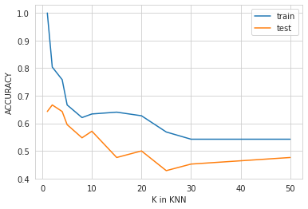

```python
plt.plot(params, train_metrics, label="train")
plt.plot(params, test_metrics, label="test")
plt.legend()
plt.xlabel("K in KNN")
plt.ylabel("ACCURACY");
```

**k = 5 - вполне нормально**

На самом деле, это не самый лучший способ подбирать гиперпараметры, но способы получше мы рассмотрим в следующий раз, а пока что выберите оптимальное значение k, сделайте предсказания и посмотрите, насколько хорошо ваша модель предсказывает каждый из классов.

### 1.5. Многоклассоввая классификация (2 балла)

Теперь нужно научиться предсказывать все 10 классов. Для этого в начале напишем соответствующий метод у нашего классификатора.

```python
knn_classifier = KNNClassifier(k=2)
knn_classifier.fit(X_train, y_train)
```

```python
predictions = knn_classifier.predict(X_test)
predictions
```

```
array(['8', '1', '3', '6', '9', '5', '5', '7', '0', '0', '0', '6', '0',
       '8', '2', '3', '9', '1', '1', '2', '8', '4', '2', '5', '6', '0',
       '2', '1', '2', '7', '0', '7', '4', '0', '4', '8', '4', '9', '7',
       '3', '0', '5', '1', '0', '8', '2', '0', '3', '0', '7', '7', '1',
       '9', '7', '1', '4', '3', '8', '4', '1', '2', '9', '1', '0', '1',
       '8', '9', '5', '5', '6', '6', '1', '2', '4', '7', '3', '3', '9',
       '8', '1', '2', '2', '8', '3', '8', '9', '2', '3', '0', '2', '5',
       '8', '8', '0', '7', '3', '6', '8', '1', '1', '0', '3', '8', '2',
       '7', '0', '9', '5', '1', '3', '3', '9', '4', '4', '2', '3', '4',
       '4', '0', '7', '2', '5', '4', '3', '6', '0', '1', '2', '8', '0',
       '4', '5', '1', '8', '4', '2', '2', '1', '7', '3', '2', '8', '0',
       '2', '9', '2', '4', '1', '4', '3', '0', '8', '0', '5', '9', '9',
       '0', '8', '3', '4', '3', '0', '7', '7', '7', '7', '3', '2', '1',
       '3', '4', '9', '1', '9', '9', '1', '0', '1', '2', '4', '0', '0',
       '7', '7', '3', '2', '3', '1', '3', '2', '8', '5', '5', '5', '9',
       '3', '3', '3', '6', '1'], dtype=object)
```

Осталось реализовать метрику качества для многоклассовой классификации, для этого реализуйте функцию `multiclass_accuracy` в `metrics.py`.

```python
multiclass_accuracy(predictions, y_test)
```

```
0.74
```

Снова выберите оптимальное значение K как мы делали для бинарной классификации.

```python
params = [1, 2, 4, 5, 8, 10, 20, 30]
train_metrics, test_metrics = find_best_k(X_train, y_train, X_test, y_test, params, accuracy_score)
```

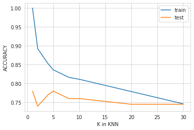

```python
plt.plot(params, train_metrics, label="train")
plt.plot(params, test_metrics, label="test")
plt.legend()
plt.xlabel("K in KNN")
plt.ylabel("ACCURACY");
```

**k= 5 - вполне нормально**

## Задание 2. KNN на датасете diabetes (10 баллов)

Теперь попробуем применить KNN к задаче регрессии. Будем работать с [данными](https://scikit-learn.org/stable/datasets/toy_dataset.html#diabetes-dataset) о диабете. В этом задании будем использовать класс `KNeighborsRegressor` из библиотеки `sklearn`. Загрузим необходимые библиотеки:

```python
from sklearn.datasets import load_diabetes
from sklearn.metrics import r2_score, mean_absolute_error, mean_squared_error
from sklearn.preprocessing import StandardScaler
from sklearn.neighbors import KNeighborsRegressor

from metrics import r_squared, mse, mae
```

```python
X, y = load_diabetes(as_frame=True, return_X_y=True)
```

```python
new_colnames = dict(zip(X.columns[4:],["tc", "ldl", "hdl","tch", "ltg", "glu"]))
X = X.rename(columns=new_colnames)
X.head()
```

|  | age | sex | bmi | bp | tc | ldl | hdl | tch | ltg | glu |
| --- | --- | --- | --- | --- | --- | --- | --- | --- | --- | --- |
| 0 | 0.038076 | 0.050680 | 0.061696 | 0.021872 | -0.044223 | -0.034821 | -0.043401 | -0.002592 | 0.019908 | -0.017646 |
| 1 | -0.001882 | -0.044642 | -0.051474 | -0.026328 | -0.008449 | -0.019163 | 0.074412 | -0.039493 | -0.068330 | -0.092204 |
| 2 | 0.085299 | 0.050680 | 0.044451 | -0.005671 | -0.045599 | -0.034194 | -0.032356 | -0.002592 | 0.002864 | -0.025930 |
| 3 | -0.089063 | -0.044642 | -0.011595 | -0.036656 | 0.012191 | 0.024991 | -0.036038 | 0.034309 | 0.022692 | -0.009362 |
| 4 | 0.005383 | -0.044642 | -0.036385 | 0.021872 | 0.003935 | 0.015596 | 0.008142 | -0.002592 | -0.031991 | -0.046641 |

### 2.1. EDA (2 обязательных балла + 2 доп. балла за Pipeline)

Сделайте EDA, предобработайте данные так, как считаете нужным, нужна ли в данном случае стандартизация и почему? Не забудте, что если вы стандартизуете данные, то нужно считать среднее и сдандартное отклонение на тренировочной части и с помощью них трансформировать и train, и test (**если не поняли это предложение, то обязательно разберитесь**).

**Дополнительно**: Попробуйте разобраться с [`Pipeline`](https://scikit-learn.org/stable/modules/generated/sklearn.pipeline.Pipeline.html), чтобы можно было создать класс, который сразу проводит стандартизацию и обучает модель (или делает предсказание). Пайплайны очень удобны, когда нужно применять различные методы предобработки данных (в том числе и к разным столбцам), а также они позволяют правильно интегрировать предобработку данных в различные классы для поиска наилучших гиперпараметров модели (например, `GridSearchCV`).

```python
from sklearn.pipeline import Pipeline
```

```python
X.info()
```

```
<class 'pandas.core.frame.DataFrame'>
RangeIndex: 442 entries, 0 to 441
Data columns (total 10 columns):
 #   Column  Non-Null Count  Dtype
---  ------  --------------  -----
 0   age     442 non-null    float64
 1   sex     442 non-null    float64
 2   bmi     442 non-null    float64
 3   bp      442 non-null    float64
 4   tc      442 non-null    float64
 5   ldl     442 non-null    float64
 6   hdl     442 non-null    float64
 7   tch     442 non-null    float64
 8   ltg     442 non-null    float64
 9   glu     442 non-null    float64
dtypes: float64(10)
memory usage: 34.7 KB
```

### Мультиколинеарность

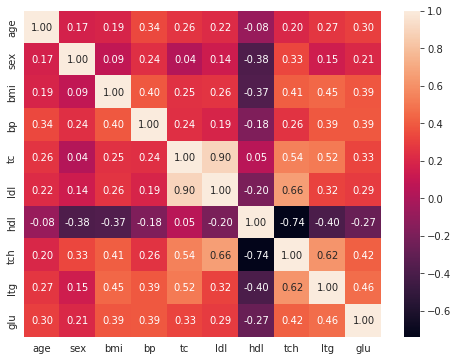

```python
plt.rcParams['figure.figsize'] = (8,6)
sns.heatmap(X.corr(), annot=True, fmt='.2f');
```

**tc, hdl, ldl, tch сильно коррелированы друг с другом, так как обозначают схожые параметры**

### Распределение целевой переменной

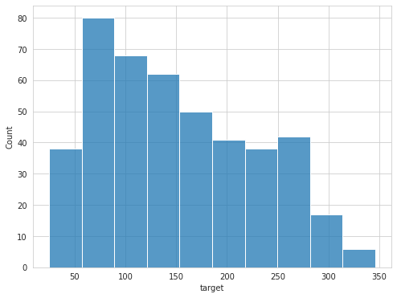

```python
sns.histplot(y);
```

В описании данных написано:  
**Note: Each of these 10 feature variables have been mean centered and scaled by the standard deviation times the square root of n_samples (i.e. the sum of squares of each column totals 1).**  
Поэтому стандартизация уже не нужна

НО! Я все равно сделаю, чтобы потренироваться в пайплайнах))

### Пусть k=5

```python
knn_pipeline = Pipeline(steps=[
    ("scaler", StandardScaler()),
    ("knn", KNeighborsRegressor(n_neighbors=5))
])
```

### 2.2. Регрессионная модель (1 балл)

Создайте модель `KNeighborsRegressor`, обучите ее на треноровочных данных и сделайте предсказания.

```python
X_train, X_test, y_train, y_test = train_test_split(X, y, test_size=0.2)
```

```python
# knn_regressor = KNeighborsRegressor(n_neighbors=5);
# knn_regressor.fit(X_train, y_train);
knn_pipeline.fit(X_train, y_train);
```

```python
y_pred = knn_pipeline.predict(X_test)
# y_pred = knn_regressor.predict(X_test)
```

### 2.3. Метрики регресии (3 балла)

Реализуйте метрики $R^2$, MSE и MAE в `metrics.py`. Примените их для оценки качества полученной модели. Все ли хорошо?

Напомню, что:

$R^2 = 1 - \frac{\sum_i^n{(y_i - \hat{y_i})^2}}{\sum_i^n{(y_i - \overline{y})^2}}$

$MSE = \frac{1}{n}\sum_i^n{(y_i - \hat{y_i})^2}$

$MAE = \frac{1}{n}\sum_i^n{|y_i - \hat{y_i}|}$

### Для k = 5

```python
r_squared(y_pred, y_test)
```

```
0.4628811790427807
```

```python
r2_score(y_test, y_pred)
```

```
0.4628811790427807
```

```python
mse(y_pred, y_test)
```

```
3776.9114606741573
```

```python
mean_squared_error(y_test, y_pred)
```

```
3776.9114606741573
```

```python
mae(y_pred, y_test)
```

```
48.997752808988764
```

```python
mean_absolute_error(y_test, y_pred)
```

```
48.997752808988764
```

### 2.4. Подбор оптимального числа соседей (2 балла)

Мы почти дошли до конца. Теперь осталось при помощи реализованных нами метрик выбрать лучшее количество соседей для нашей модели.

!!! Обратите внимание на то, что значат наши метрики, для некоторых хорошо, когда они уменьшаются, для других наоборот.

```python
from metrics import r_squared, mse, mae
```

```python
def find_best_k(X_train, y_train, X_test, y_test, params, r2=r_squared, mae=mae, mse=mse):
    """
    Choose the best k for KNeighborsRegressor

    Arguments:
    X_train, np array (num_train_samples, num_features) - train data
    y_train, np array (num_train_samples) - train labels
    X_test, np array (num_test_samples, num_features) - test data
    y_test, np array (num_test_samples) - test labels
    params, list of hyperparameters for KNN, here it is list of k values
    r2, function calculates the R squared value, r2(y_pred, y_test)
    mse, function calculates the Mean squared error value, mse(y_pred, y_test)
    mae, function calculates the Mean absolute error value, mae(y_pred, y_test)

    Returns:
    None
    """
    train_r2, test_r2, train_mse, test_mse, train_mae, test_mae = [], [], [], [], [], []

    for k in params:
        knn_pipeline = Pipeline(steps=[("scaler", StandardScaler()),
                                       ("knn", KNeighborsRegressor(n_neighbors=k))])

        knn_pipeline.fit(X_train, y_train)

        y_pred_train = knn_pipeline.predict(X_train)
        y_pred_test = knn_pipeline.predict(X_test)

        r_sq_train = r2(y_pred_train, y_train)
        r_sq_test = r2(y_pred_test, y_test)

        mse_train = mse(y_pred_train, y_train)
        mse_test = mse(y_pred_test, y_test)

        mae_train = mae(y_pred_train, y_train)
        mae_test = mae(y_pred_test, y_test)

        print(
            f'''
            <------- for k = {k} ------>:

            R2 for train data = {r_sq_train}
            R2 for test data = {r_sq_test}

            MSE for train data = {mse_train}
            MSE for test data = {mse_test}

            MAE for train data = {mae_train}
            MAE for test data = {mae_test}'''
             )

        train_r2.append(r_sq_train)
        test_r2.append(r_sq_test)

        train_mse.append(mse_train)
        test_mse.append(mse_test)

        train_mae.append(mae_train)
        test_mae.append(mae_test)

    return train_r2, test_r2, train_mse, test_mse, train_mae, test_mae
```

Для поиска лучшего k вы можете воспользоваться функцией `find_best_k`, которую вы реализовали выше.

```python
params = [1, 2, 4, 5, 8, 10, 30]
train_r2, test_r2, train_mse, test_mse, train_mae, test_mae = find_best_k(X_train, y_train, X_test, y_test, params)
```

```
            <------- for k = 1 ------>:

            R2 for train data = 1.0
            R2 for test data = 0.11841567077886195

            MSE for train data = 0.0
            MSE for test data = 6199.123595505618

            MAE for train data = 0.0
            MAE for test data = 58.247191011235955

            <------- for k = 2 ------>:

            R2 for train data = 0.7277141388907948
            R2 for test data = 0.3687555833709971

            MSE for train data = 1533.520538243626
            MSE for test data = 4438.783707865168

            MAE for train data = 29.491501416430594
            MAE for test data = 49.97191011235955

            <------- for k = 4 ------>:

            R2 for train data = 0.5766528842402701
            R2 for test data = 0.4469956692843974

            MSE for train data = 2384.301168555241
            MSE for test data = 3888.6151685393256

            MAE for train data = 37.57577903682719
            MAE for test data = 48.89887640449438

            <------- for k = 5 ------>:

            R2 for train data = 0.5516096095483172
            R2 for test data = 0.4628811790427807

            MSE for train data = 2525.3454957507083
            MSE for test data = 3776.9114606741573
```

[output cut: 21 more lines]

```
            MSE for test data = 3798.8638202247193

            MAE for train data = 41.54249291784703
            MAE for test data = 50.59775280898876

            <------- for k = 30 ------>:

            R2 for train data = 0.4690172615539585
            R2 for test data = 0.39211302177796503

            MSE for train data = 2990.507592067989
            MSE for test data = 4274.538901373284

            MAE for train data = 44.446836638338056
            MAE for test data = 55.09213483146067
```

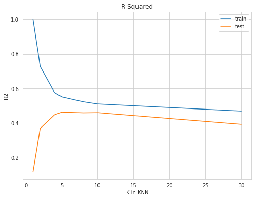

```python
plt.plot(params, train_r2, label="train")
plt.plot(params, test_r2, label="test")
plt.legend()
plt.xlabel("K in KNN")
plt.ylabel("R2");
plt.title('R Squared');
```

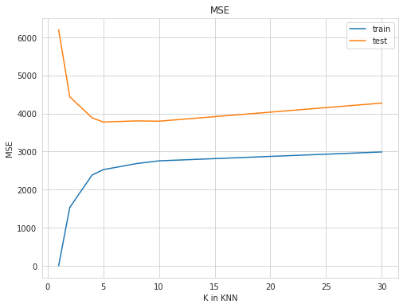

```python
plt.plot(params, train_mse, label="train")
plt.plot(params, test_mse, label="test")
plt.legend()
plt.xlabel("K in KNN")
plt.ylabel("MSE");
plt.title('MSE');
```

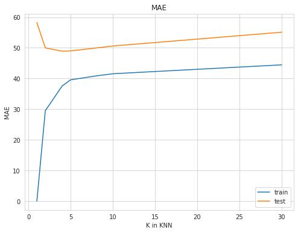

```python
plt.plot(params, train_mae, label="train")
plt.plot(params, test_mae, label="test")
plt.legend()
plt.xlabel("K in KNN")
plt.ylabel("MAE");
plt.title('MAE');
```

### Кажется, значение k = 10 будет вполне приемлимо

### 3. Социализация (0.5 доп. балла)

Так как у нас теперь большая группа, то было бы здорово всем познакомиться получше (так как выпускной не за горами). Соберитесь с одногруппниками в зуме (желательно, чтобы были люди и с Онлайна, и с Питера), познакомьтесь, а сюда прикрепите скриншот с камерами всех участников.

## Therapy time

Напишите здесь ваши впечатления о задании: было ли интересно, было ли слишком легко или наоборот сложно и тд. Также сюда можно написать свои идеи по улучшению заданий, а также предложить данные, на основе которых вы бы хотели построить следующие дз.

**Ваши мысли:**

# Спасибо, что отвечаете на вопросы!